# Predictors of frog survival following translocations - supplemental analyses

Roland Knapp

The following are supplemental analyses, some related to analyses in `translocation_survival_analysis.Rmd` and some unrelated.

## Load packages

```r
library(tidyverse)
library(rstanarm)
library(bayesplot)
library(tidybayes)
library(loo)
library(broom.mixed)
library(janitor)
```

## ANALYSIS 1: Analysis of changes in Bd load following translocation

- Compare loads at time of translocation to those from CMR years 0 and 1. Exclude years > 1. Only frogs that were recaptured at least once following translocation are included.
- Model with pit_tag_ref as grouping variable is the model of primary interest, roughly analogous to paired t-test. Included other models to allow a better understanding of the data.

### Read in frog-Bd dataset

```r
d1 <- read_csv(here::here("data", "clean", "bd_beforeafter_translocation.csv"))
```

- site_id: Unique 5-digit site identifier.
- site_id1: Assigned 5-digit site identifier for a collection of adjacent sites that are utilized by a frog population.
- translocation_id: Unique identifier for each translocation.
- visit_date: Date on which translocation or survey was conducted.
- survey_type: “translocation” or “cmr”.
- period: “before” or “after” translocation.
- year_translocate: Year in which translocation was conducted.
- year_capture: Year in which frog was captured.
- interval: Number of years between translocation and frog capture.
- pit_tag_ref: Unique PIT tag identifier.
- swab_id: Unique identifier for skin swab sample.
- bd_load: Bd infection intensity determined from skin swab samples, units are number of ITS1 copies * 80.

### Data exploration

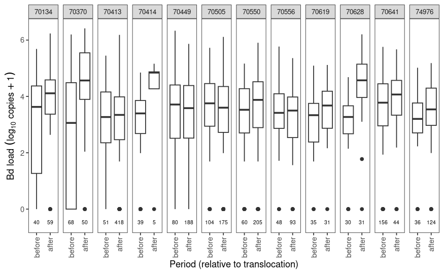

- In most cases, relatively small increases in load following translocation.

### Prepare variables for analysis

```r
d1 <- d1 %>%
  mutate(after = if_else(period == "after", 1, 0),
         bd_load = as.integer(round(bd_load)),
         after_c = after - mean(after))
```

### Check for null values

```r
d1 %>% summarize(across(everything(), ~ sum(is.na(.))))
```

### Include only CMR years 0 and 1

```r
d2 <- d1 %>%
  filter(interval < 2)
```

### Plot distribution of bd_load response variable

```r
d2 %>%
  ggplot(aes(x = bd_load)) +
    geom_histogram()

d2 %>%
  ggplot(aes(sample = bd_load)) +
    geom_qq() +
    geom_qq_line()
```

### Model without group-level effects

#### Model specification

```r
m1a <- stan_glm(
  bd_load ~ after_c,
  data = d2,
  family = neg_binomial_2(),
  chains = 4,
  iter = 5000*2,
  cores = 4,
  seed = 84735)
```

#### Priors and chain diagnostics

```r
prior_summary(m1a)

mcmc_trace(m1a, size = 0.1)
mcmc_dens_overlay(m1a)

summary(m1a)
```

#### Posterior predictive check

```r
pp_check(m1a, plotfun = "stat") +
    xlab("Bd load")
```

- Posterior predictive distribution implied by regression model closely matches original data (based on mean Bd load).

#### Calculate loo

```r
loo_m1a <- loo(m1a, cores = 4, save_psis = TRUE)
print(loo_m1a)
```

#### Posterior analysis

```r
tidy(m1a, conf.int = TRUE, conf.level = 0.90)

mcmc_areas(m1a, area_method = "equal height", prob = 0.90) +
  geom_vline(xintercept = 0, color = "red", linetype = "dashed", lwd = 0.5) +
  ggtitle("Model with standardized predictors, no group-level effects",
          "Posterior distributions with medians & 90% uncertainty intervals")
```

### Model with 1 grouping variable: pit_tag_ref

#### Model specification

```r
m1b <- stan_glmer(
  bd_load ~ after_c + (1 | pit_tag_ref),
  data = d2,
  family = neg_binomial_2(),
  chains = 4,
  iter = 5000*2,
  cores = 4,
  seed = 84735)
```

#### List model variable names

```r
get_variables(m1b)
```

#### Priors and chain diagnostics

```r
prior_summary(m1b)

b1 <- c("(Intercept)", "after_c")

mcmc_trace(m1b, size = 0.1, pars = b1)
mcmc_dens_overlay(m1b, pars = b1)

summary(m1b)
```

#### Posterior predictive check

```r
pp_check(m1b, plotfun = "stat") +
    xlab("Bd load")
```

- Posterior predictive distribution implied by regression model shows some mismatch between actual data and model results (based on mean Bd load).

#### Calculate loo

```r
loo_m1b <- loo(m1b, cores = 4, save_psis = TRUE)
print(loo_m1b)
```

#### Posterior analysis

```r
tidy(m1b, conf.int = TRUE, conf.level = 0.90)

mcmc_areas(m1b, area_method = "equal height", prob = 0.90, pars = b1) +
  geom_vline(xintercept = 0, color = "red", linetype = "dashed", lwd = 0.5) +
  ggtitle("Model with pit_tag_ref as grouping variable",
          "Posterior distributions with medians & 90% uncertainty intervals")
```

### Model with 2 grouping variables: pit_tag_ref nested within translocation_id

#### Model specification

```r
m1c <- stan_glmer(
  bd_load ~ after_c + (1 | pit_tag_ref) + (1 | translocation_id),
  data = d2,
  family = neg_binomial_2(),
  chains = 4,
  iter = 5000*2,
  cores = 4,
  seed = 84735)
```

#### Priors and chain diagnostics

```r
prior_summary(m1c)

b1 <- c("(Intercept)", "after_c")

mcmc_trace(m1c, size = 0.1, pars = b1)
mcmc_dens_overlay(m1c, pars = b1)

summary(m1c)
```

#### Posterior predictive check

```r
pp_check(m1c, plotfun = "stat") +
    xlab("Bd load")
```

- Posterior predictive distribution implied by regression model closely matches original data (based on mean Bd load).

#### Calculate loo

```r
loo_m1c <- loo(m1c, cores = 4, save_psis = TRUE)
print(loo_m1c)
```

#### Posterior analysis

```r
tidy(m1c, conf.int = TRUE, conf.level = 0.90)

mcmc_areas(m1c, area_method = "equal height", prob = 0.90, pars = b1) +
  geom_vline(xintercept = 0, color = "red", linetype = "dashed", lwd = 0.5) +
  ggtitle("Model with pit_tag_ref and translocation_id as grouping variables",
          "Posterior distributions with medians & 90% uncertainty intervals")
```

### Model with 2 grouping variables: pit_tag_ref nested within site_id1

#### Model specification

```r
m1d <- stan_glmer(
  bd_load ~ after_c + (1 | pit_tag_ref) + (1 | site_id1),
  data = d2,
  family = neg_binomial_2(),
  chains = 4,
  iter = 5000*2,
  cores = 4,
  seed = 84735)
```

#### Priors and chain diagnostics

```r
prior_summary(m1d)

b1 <- c("(Intercept)", "after_c")

mcmc_trace(m1d, size = 0.1, pars = b1)
mcmc_dens_overlay(m1d, pars = b1)

summary(m1d)
```

#### Posterior predictive check

```r
pp_check(m1d, plotfun = "stat") +
    xlab("Bd load")
```

- Posterior predictive distribution implied by regression model closely matches original data (based on mean Bd load).

#### Calculate loo

```r
loo_m1d <- loo(m1d, cores = 4, save_psis = TRUE)
print(loo_m1d)
```

#### Posterior analysis

```r
tidy(m1d, conf.int = TRUE, conf.level = 0.90)

mcmc_areas(m1d, area_method = "equal height", prob = 0.90, pars = b1) +
  geom_vline(xintercept = 0, color = "red", linetype = "dashed", lwd = 0.5) +
  ggtitle("Model with pit_tag_ref and site_id1 as grouping variables",
          "Posterior distributions with medians & 90% uncertainty intervals")
```

### Compare 4 models with different grouping structures

```r
loo_compare(loo_m1a, loo_m1b, loo_m1c, loo_m1d)
```

- All models are equivalent, so pairing before-after by pit_tag_ref is unimportant.

## ANALYSIS 2: Evaluate effect of frog size independent of donor population

- Model m1d from `translocation_survival_analysis.Rmd` but using data subset where donor = 72996 only.

### Read in frog translocation dataset

- arm package used to rescale continuous variables (substract mean, divide by 2 SD), manual centering of binary variables.

```r
d1 <- read_csv(here::here("data", "clean", "frog_translocation_final.csv")) %>%
  drop_na(bd_load) %>%  # drop 12 records where bd_load is NA (9 are from 70413)
  mutate(
    first = if_else(order == 1, 1, 0),
    surv = if_else(survival < 0.5, 0, 1),
    male = if_else(sex == "m", 1, 0),
    elev_lo = if_else(elevation < 3020, 1, 0), # using interval defined by cut_interval, n = 2
    elev_z = arm::rescale(elevation),
    snowt_z = arm::rescale(snow_t),
    snowt1_z = arm::rescale(snow_t1),
    day_z = arm::rescale(day),
    length_z = arm::rescale(length),
    bdload_l = log10(bd_load + 1),
    bdload_z = arm::rescale(bdload_l),
    shore_c = shore - mean(shore),
    male_c = male - mean(male),
    elevlo_c = elev_lo - mean(elev_lo),
    first_c = first - mean(first),
    across(c(shore_c, male_c, elevlo_c, first_c), round, 3),
    across(c(site_id, shore_c, first_c, donor, male_c, elevlo_c, year), as.factor),
    surv = as.integer(surv))

# Add a descriptive translocation_id
d1 <- d1 %>%
  distinct(site_id, year) %>%
  arrange(site_id, year) %>%
  group_by(site_id) %>%
  mutate(transno = seq_len(n())) %>%
  ungroup(site_id) %>%
  unite(translocation_id, c("site_id", "transno"), remove = FALSE) %>%
  select(-transno) %>%
  mutate(translocation_id = as.factor(translocation_id)) %>%
  inner_join(d1, by = c("site_id", "year")) %>%
  relocate(translocation_id, .after = site_id)
```

### Model specification

```r
d1_72996 <- d1 %>%
  filter(donor == "72996" & !is.na(bd_load))

m1d_72996 <- stan_glmer(
  surv ~ length_z + snowt_z + snowt1_z + day_z + bdload_z + elev_z + first_c + male_c + (1 | translocation_id),
  data = d1_72996,
  family = binomial,
  chains = 4,
  iter = 5000*2,
  cores = 4,
  seed = 84735)
```

### Priors & chain diagnostics

```r
prior_summary(m1d_72996)

b1_72996 <- c("(Intercept)", "length_z", "snowt_z", "snowt1_z", "day_z", "bdload_z", "elev_z", "first_c0.353", "male_c0.548")

mcmc_trace(m1d_72996, size = 0.1, pars = b1_72996)
mcmc_dens_overlay(m1d_72996, pars = b1_72996)

summary(m1d_72996)
```

### Posterior predictive check

```r
pp_check(m1d_72996, plotfun = "stat") +
    xlab("Frog survival rate")
```

### Posterior analysis

```r
tidy(m1d_72996, conf.int = TRUE, conf.level = 0.90)

mcmc_areas(m1d_72996, area_method = "equal height", prob = 0.90, pars = b1_72996) +
  geom_vline(xintercept = 0, color = "red", linetype = "dashed", lwd = 0.5) +
  ggtitle("Model with standardized predictors & translocation_id as grouping variable",
          "Posterior distributions with medians & 90% uncertainty intervals")

mean(bayes_R2(m1d_72996))

# Frog survival by translocation_id
mcmc_areas_ridges(m1d_72996, regex_pars = "translocation_id") +
  geom_vline(xintercept = 0, color = "red", linetype = "dashed", lwd = 0.5) +
  ggtitle("Frog survival for each translocation_id")
```

## ANALYSIS 3: Assess effect on m1d of including all records, including where bd_load = NA

- Additional analysis of model m1d from `translocation_survival_analysis.Rmd`.

### Read in frog translocation dataset

- arm package used to rescale continuous variables (substract mean, divide by 2 SD), manual centering of binary variables.

```r
d1_allna <- read_csv(here::here("data", "clean", "frog_translocation_final.csv")) %>%
  mutate(
    first = if_else(order == 1, 1, 0),
    surv = if_else(survival < 0.5, 0, 1),
    male = if_else(sex == "m", 1, 0),
    elev_lo = if_else(elevation < 3020, 1, 0), # using interval defined by cut_interval, n = 2
    elev_z = arm::rescale(elevation),
    snowt_z = arm::rescale(snow_t),
    snowt1_z = arm::rescale(snow_t1),
    day_z = arm::rescale(day),
    length_z = arm::rescale(length),
    bdload_l = log10(bd_load + 1),
    bdload_z = arm::rescale(bdload_l),
    shore_c = shore - mean(shore),
    male_c = male - mean(male),
    elevlo_c = elev_lo - mean(elev_lo),
    first_c = first - mean(first),
    across(c(shore_c, male_c, elevlo_c, first_c), round, 3),
    across(c(site_id, shore_c, first_c, donor, male_c, elevlo_c, year), as.factor),
    surv = as.integer(surv))

# Add a descriptive translocation_id
d1_allna <- d1_allna %>%
  distinct(site_id, year) %>%
  arrange(site_id, year) %>%
  group_by(site_id) %>%
  mutate(transno = seq_len(n())) %>%
  ungroup(site_id) %>%
  unite(translocation_id, c("site_id", "transno"), remove = FALSE) %>%
  select(-transno) %>%
  mutate(translocation_id = as.factor(translocation_id)) %>%
  inner_join(d1_allna, by = c("site_id", "year")) %>%
  relocate(translocation_id, .after = site_id)
```

### Model specification

```r
m1d_allna <- stan_glmer(
  surv ~ length_z + snowt_z + snowt1_z + day_z + elev_z + first_c + male_c + donor + (1 | translocation_id),
  data = d1_allna,
  family = binomial,
  chains = 4,
  iter = 5000*2,
  cores = 4,
  seed = 84735)
```

### List model variable names

```r
get_variables(m1d_allna)
```

### Priors & chain diagnostics

```r
prior_summary(m1d_allna)

b1_allna <- c("(Intercept)", "length_z", "snowt_z", "snowt1_z", "day_z", "elev_z", "first_c0.349", "male_c0.549", "donor70567", "donor72996")

mcmc_trace(m1d_allna, size = 0.1, pars = b1_allna)
mcmc_dens_overlay(m1d_allna, pars = b1_allna)

summary(m1d_allna)
```

### Posterior predictive check

```r
pp_check(m1d_allna, plotfun = "stat") +
    xlab("Frog survival rate")
```

### Posterior analysis

```r
tidy(m1d_allna, conf.int = TRUE, conf.level = 0.90)

mcmc_areas(m1d_allna, area_method = "equal height", prob = 0.90, pars = b1_allna) +
  geom_vline(xintercept = 0, color = "red", linetype = "dashed", lwd = 0.5) +
  ggtitle("Model with standardized predictors & translocation_id as grouping variable",
          "Posterior distributions with medians & 90% uncertainty intervals")

mean(bayes_R2(m1d_allna))

# Frog survival by translocation_id
mcmc_areas_ridges(m1d_allna, regex_pars = "translocation_id") +
  geom_vline(xintercept = 0, color = "red", linetype = "dashed", lwd = 0.5) +
  ggtitle("Frog survival for each translocation_id")
```

- Inclusion of all records (i.e., 12 records where bd_load = NA that were excluded in primary analysis) did not change the results.